# Mini Proyecto 2025. Análisis de tickets de supermercado

Tratamiento de Datos. Grado en Ciencia de Datos - UV

Grupo G: Lucía Torcal Valdivia, Clara Soriano Solaz, Yelyzaveta Domashova, Sergi Albuixech Sanfélix y Ronal Felipe Garcia Marin

2025-04-13

# Introducción

Relización del proyecto en la asignatura: Tratamiento de los Datos, del grado de Ciencia de Datos del primer curso. La finalidad de este proyecto es la realización de un análisis exploratorio de los datos que se han recopilado en varios tickets de Mercadona.

## Importación

Una vez cargadas las librerías necesarias, se procederá a importar los datos. Para ello, se obtiene el listado de todos los tickets ubicados en una carpeta específica.

La lectura de un ticket se organiza en una función que sigue varios pasos. Primero, se establece la codificación en UTF-8 para evitar errores posteriores, ya que algunos archivos pueden tener formatos diferentes.

A continuación, se analiza la cabecera del recibo, asignando cada línea a una variable: nombre del supermercado, dirección, etc. En ciertos casos, una línea puede contener varios datos, como la fecha y la hora, que separaremos más adelante.

Con esta información se crea un primer dataframe. Luego se extraen los productos del ticket para construir un segundo conjunto de datos. Finalmente, se añade el total de la compra, que suele aparecer tras los productos, al dataframe principal por tratarse de un valor único por ticket.

El siguiente paso consiste en generar una lista con todos los tickets disponibles y aplicar sobre cada uno la función definida anteriormente.

Una vez procesados los tickets, se unifican los dataframes y se separan las variables combinadas, como la ubicación o la fecha y hora, en columnas independientes.

La importación continúa separando cantidad, producto y precio en un nuevo dataframe, que luego se une con el de cabeceras para relacionar cada producto con su compra correspondiente.

Para finalizar la imputación de datos, se identifican las líneas que contienen pesos de productos y se asocian a su nombre correspondiente, dando lugar a tres dataframes finales: uno con los productos, otro con la información general y un tercero con todos los datos integrados.

1. ¿Cuáles son los 5 productos, de los vendidos por unidades, con más ventas ? ¿Cuántas unidades de cada uno se han vendido ?
2. Si consideramos la categoría de FRUTAS Y VERDURAS. Cuáles son los 5 productos más vendidos ? ¿Cuántos kilos se han vendido de cada uno de estos productos ?
3. Si consideramos la categoría de PESCADO. Cuáles son los 5 productos más vendidos ? ¿Cuántos kilos se han vendido de cada uno de estos productos ?
4. Muestra mediante un gráfico de líneas como ha variado el precio por kilo de las bananas y los plátanos en los tickets disponibles, a lo largo del tiempo.
5. ¿ Cuál es la procedencia de los tickets ?¿ Qué ciudad/ pueblo tiene un mayor número de tickets ?
6. Muestra mediante un diagrama el número de tickets recogidos cada día de las semana. ¿Si tuvieses que cerrar un día entre semana qué día lo harías ?

Preguntas propuestas:

#1. ¿Cuáles son los 5 productos, de los vendidos por unidades, con más ventas ? ¿Cuántas unidades de cada uno se han vendido ?

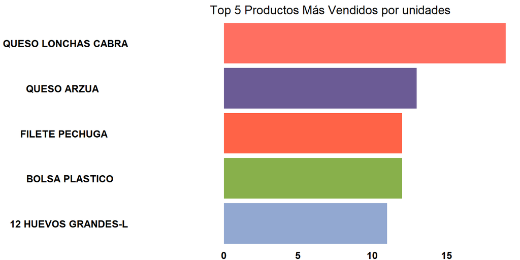

Productos más vendidos por unidades

Como podemos observar en el gráfico, los productos más vendidos por unidad son: Queso de lonchas de cabra, Queso Arzua, filete pechuga, bolsas de plástico y 12 huevos grandes talla L, siendo el más vendido el queso de lonchas de cabra.

#2 Si consideramos la categoría de FRUTAS Y VERDURAS. Cuáles son los 5 productos más vendidos ? ¿Cuántos kilos se han vendido de cada uno de estos productos ?

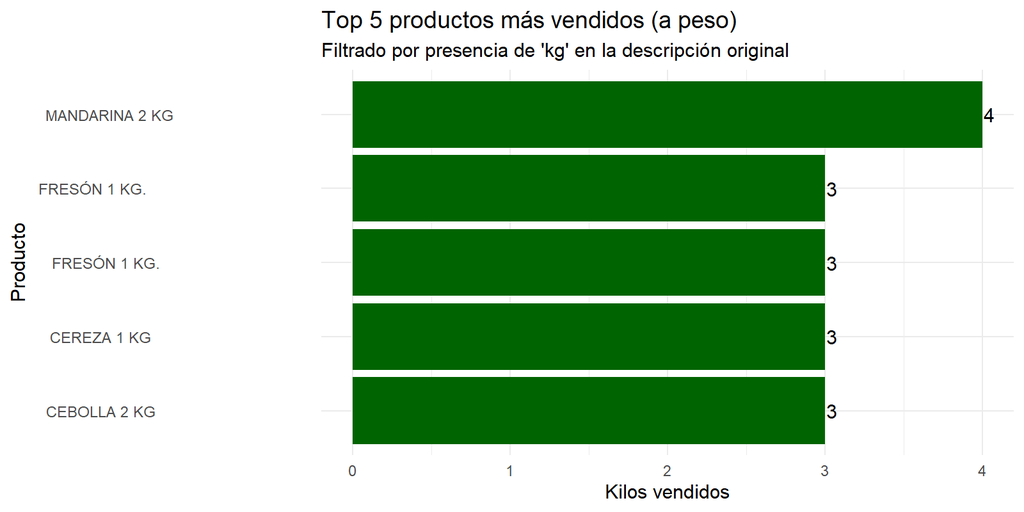

```r
library(dplyr)
library(ggplot2)
library(stringr)

# Paso 1: Filtrar solo productos vendidos "a peso" (que tenían 'kg' en la descripción original)
frutas_verduras_peso <- datos_integrados %>%
  filter(!is.na(Cantidad)) %>%
  filter(str_detect(tolower(Producto), "kg"))

# Paso 2: Agrupar por producto y sumar kilos
top_frutas_verduras <- frutas_verduras_peso %>%
  group_by(Producto) %>%
  summarise(Kilos_vendidos = sum(Cantidad)) %>%
  arrange(desc(Kilos_vendidos)) %>%
  slice_head(n = 5)

# Paso 3: Gráfico
ggplot(top_frutas_verduras, aes(x = reorder(Producto, Kilos_vendidos), y = Kilos_vendidos)) +
  geom_col(fill = "darkgreen") +
  geom_text(aes(label = round(Kilos_vendidos, 1)), hjust = -0.1) +
  coord_flip() +
  labs(title = "Top 5 productos más vendidos (a peso)",
       subtitle = "Filtrado por presencia de 'kg' en la descripción original",
       x = "Producto",
       y = "Kilos vendidos") +
  theme_minimal()
```

#3 Si consideramos la categoría de PESCADO. Cuáles son los 5 productos más vendidos ? ¿Cuántos kilos se han vendido de cada uno de estos productos ?

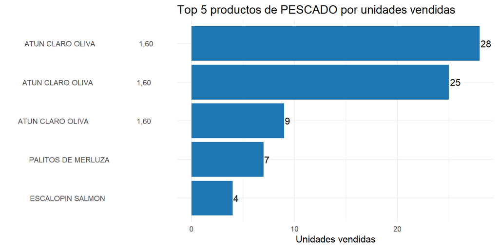

```r
library(dplyr)
library(ggplot2)

# Filtramos productos de pescado (sin filtrar por "kg" ahora)
top_pescado_unidades <- datos_integrados %>%
  filter(str_detect(tolower(Producto), "pescado|salmon|merluza|atun|bacalao|dorada|lubina|sardina|boqueron|rape")) %>%
  group_by(Producto) %>%
  summarise(Unidades_vendidas = sum(Cantidad)) %>%  # Suma unidades, no kilos
  arrange(desc(Unidades_vendidas)) %>%
  slice_head(n = 5)

# Gráfico de unidades
ggplot(top_pescado_unidades, aes(x = reorder(Producto, Unidades_vendidas), y = Unidades_vendidas)) +
  geom_col(fill = "#1f77b4") +
  geom_text(aes(label = Unidades_vendidas), hjust = -0.1) +
  coord_flip() +
  labs(
    title = "Top 5 productos de PESCADO por unidades vendidas",
    x = "",
    y = "Unidades vendidas"
  ) +
  theme_minimal()
```

# 1. ¿Cuál es el promedio de productos por ticket?

```r
# Suponiendo que 'df' tiene todas las filas de productos con sus columnas de cabecera:
promedio_por_ticket <- df %>%
  # Agrupar por un identificador único de ticket; aquí usamos todas las columnas de cabecera
  group_by(Supermercado, Calle, CP, Ubicacion, Telefono, Fecha, Hora) %>%
  summarise(n_productos = n(), .groups = "drop") %>%
  summarise(promedio = mean(n_productos))

promedio_por_ticket
```

```
# A tibble: 1 × 1
  promedio
     <dbl>
1     19.0
```

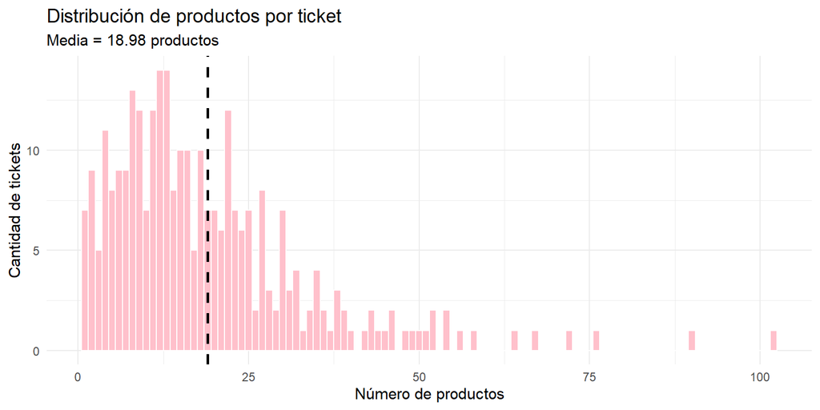

```r
# 1) Calcular nº de productos por ticket
tickets_productos <- df %>%
  group_by(Supermercado, Calle, CP, Ubicacion, Telefono, Fecha, Hora) %>%
  summarise(n_productos = n(), .groups = 'drop')

# 2) Calcular la media
media_prod <- mean(tickets_productos$n_productos)

# 3) Graficar
ggplot(tickets_productos, aes(x = n_productos)) +
  geom_histogram(binwidth = 1, fill = "pink", color = "white") +
  geom_vline(xintercept = media_prod, linetype = "dashed", linewidth = 1) +
  labs(
    title    = "Distribución de productos por ticket",
    subtitle = paste0("Media = ", round(media_prod, 2), " productos"),
    x        = "Número de productos",
    y        = "Cantidad de tickets"
  ) +
  theme_minimal()
```

#2. ¿Qué categoría representa el mayor porcentaje del gasto total?

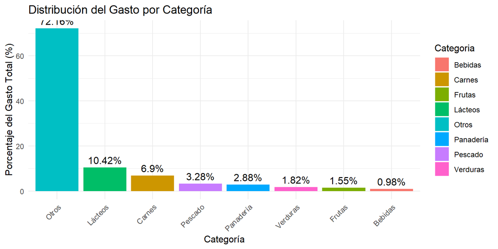

```r
library(dplyr)
library(stringr)

# Crear categorías basadas en palabras clave (si no existe la columna)
datos_con_categorias <- datos_integrados %>%
  mutate(
    Categoria = case_when(
      str_detect(tolower(Producto), "leche|yogur|queso|mantequilla") ~ "Lácteos",
      str_detect(tolower(Producto), "pescado|salmón|atún|bacalao|merluza") ~ "Pescado",
      str_detect(tolower(Producto), "fruta|plátano|manzana|naranja|pera") ~ "Frutas",
      str_detect(tolower(Producto), "verdura|lechuga|tomate|cebolla|zanahoria") ~ "Verduras",
      str_detect(tolower(Producto), "carne|pollo|cerdo|ternera|filete") ~ "Carnes",
      str_detect(tolower(Producto), "pan|bollería|baguette") ~ "Panadería",
      str_detect(tolower(Producto), "agua|refresco|zumo|coca cola") ~ "Bebidas",
      TRUE ~ "Otros"  # Categoría por defecto
    )
  )

gasto_por_categoria <- datos_con_categorias %>%
  group_by(Categoria) %>%
  summarise(
    Gasto_Total = sum(precio_prod * Cantidad, na.rm = TRUE)
  ) %>%
  mutate(
    Porcentaje = (Gasto_Total / sum(Gasto_Total)) * 100,
    Porcentaje = round(Porcentaje, 2)
  ) %>%
  arrange(desc(Gasto_Total))

categoria_mayor_gasto <- gasto_por_categoria %>%
  slice(1)  # Toma la primera fila (la de mayor gasto)

ggplot(gasto_por_categoria, aes(x = reorder(Categoria, -Porcentaje), y = Porcentaje, fill = Categoria)) +
  geom_col() +
  geom_text(aes(label = paste0(Porcentaje, "%")), vjust = -0.5, size = 4) +
  labs(
    title = "Distribución del Gasto por Categoría",
    x = "Categoría",
    y = "Porcentaje del Gasto Total (%)"
  ) +
  theme_minimal() +
  theme(axis.text.x = element_text(angle = 45, hjust = 1))
```

#3. ¿Qué días de la semana concentran más compras?

```r
library(lubridate)  # Para manejo de fechas

# Convertir Fecha a tipo Date y extraer día de la semana
datos_con_dias <- datos_integrados %>%
  mutate(
    Fecha = as.Date(Fecha, format = "%d/%m/%Y"),  # Ajusta el formato según tus datos
    Dia_Semana = weekdays(Fecha),  # Nombre del día (ej: "lunes")
    Dia_Semana = factor(Dia_Semana, levels = c("lunes", "martes", "miércoles", "jueves", "viernes", "sábado", "domingo"))
  )

compras_por_dia <- datos_con_dias %>%
  group_by(Fecha, Dia_Semana) %>%
  summarise(Num_Tickets = n_distinct(Supermercado, Fecha, Hora), .groups = "drop") %>%  # Tickets únicos
  group_by(Dia_Semana) %>%
  summarise(Total_Compras = sum(Num_Tickets)) %>%
  arrange(desc(Total_Compras))

compras_por_dia
```

```
# A tibble: 8 × 2
  Dia_Semana Total_Compras
  <fct>              <int>
1 sábado                80
2 lunes                 50
3 viernes               46
4 martes                42
5 miércoles             40
6 jueves                32
7 <NA>                   3
8 domingo                1
```

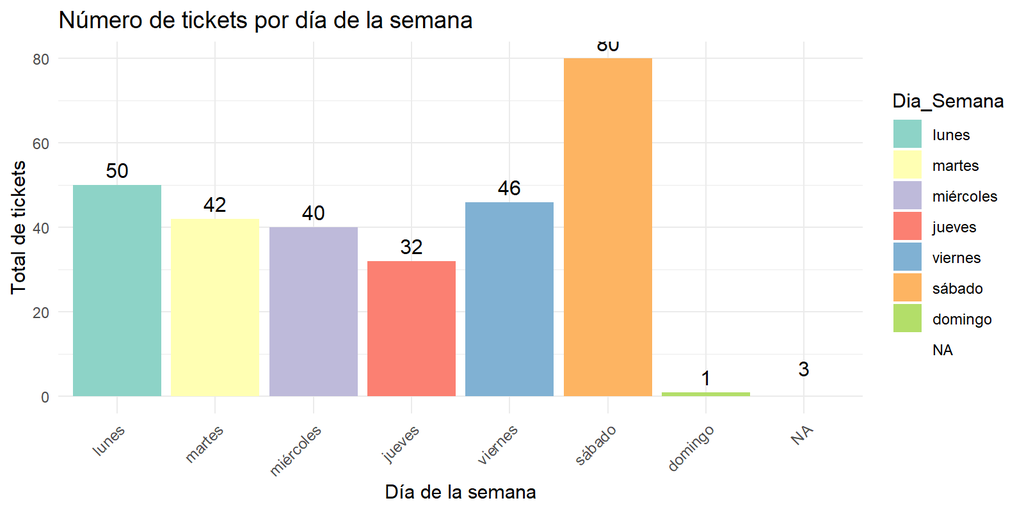

```r
# Día con más compras
dia_max_compras <- compras_por_dia %>% slice(1)

ggplot(compras_por_dia, aes(x = Dia_Semana, y = Total_Compras, fill = Dia_Semana)) +
  geom_col() +
  geom_text(aes(label = Total_Compras), vjust = -0.5, size = 4) +
  labs(
    title = "Número de tickets por día de la semana",
    x = "Día de la semana",
    y = "Total de tickets"
  ) +
  scale_fill_brewer(palette = "Set3") +
  theme_minimal() +
  theme(axis.text.x = element_text(angle = 45, hjust = 1))
```

Como podemos observar en el gráfico, el sábado es el dia de la semana en el que se concentran más compras.

#4. ¿Cuáles son los 5 productos más baratos comprados por unidad? ¿Con qué frecuencia se compran?

```r
library(dplyr)
library(ggplot2)
library(stringr)

# 1. Filtrar productos por unidad (sin 'kg' en el nombre)
por_unidad <- datos_integrados %>%
  filter(!is.na(Cantidad), Cantidad > 0) %>%
  filter(!str_detect(tolower(Producto), "kg"))

# 2. Calcular precio unitario
por_unidad <- por_unidad %>%
  mutate(Precio_unitario = precio_prod / Cantidad)

# 3. Agrupar por producto, calcular media y frecuencia
top_baratos <- por_unidad %>%
  group_by(Producto) %>%
  summarise(
    Precio_unitario_medio = round(mean(Precio_unitario, na.rm = TRUE), 2),
    Frecuencia = n(),
    .groups = "drop"
  ) %>%
  arrange(Precio_unitario_medio) %>%
  slice_head(n = 5)

# 4. Mostrar tabla
print(top_baratos)
```

```
# A tibble: 5 × 3
  Producto                                             Precio_unitario_medio Frecuencia
  <chr>                                                                <dbl>      <int>
1 " MEJILLONES ESCABECHE          2,50           1"                     0             1
2 "   POLLO CERTIFICADO E                           1"                  0.03          1
3 "1%                    0,83              "                            0.09          1
4 "   BOLSA PLASTICO                                 "                  0.15          2
5 " BOLSA PLASTICO                               "                      0.15          2
```

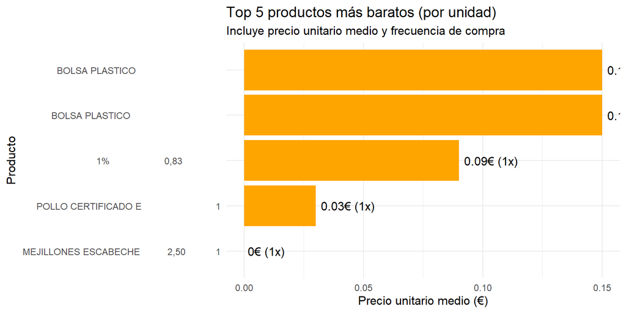

```r
# 5. Gráfico de barras (precio unitario medio)
ggplot(top_baratos, aes(x = reorder(Producto, Precio_unitario_medio), y = Precio_unitario_medio)) +
  geom_col(fill = "orange") +
  geom_text(aes(label = paste0(Precio_unitario_medio, "€ (", Frecuencia, "x)")), hjust = -0.1) +
  coord_flip() +
  labs(title = "Top 5 productos más baratos (por unidad)",
       subtitle = "Incluye precio unitario medio y frecuencia de compra",
       x = "Producto",
       y = "Precio unitario medio (€)") +
  theme_minimal()
```